# Predicting House Prices in Philadelphia with OLS

Timothy Oliver and Jarred Randall

11 October 2023

# Introduction

The housing market is very volatile, so understanding what factors contribute to that volatility is extremely important. Zillow has expressed concerns that their housing market predictions are not as accurate as they could be. The biggest contributor to the inaccurate predictions of their current model is that they do not factor in enough local intelligence. Local intelligence is defined as a home’s spatial relationships with its surrounding environment such as distances to amenities and public services or the amount of crime that occurs in a specified vicinity of the house. Our strategy is to create a linear model that considers a current Zillow database about given homes in Philadelphia and incorporate open data for nearby amenities such as landmarks, parks, school catchments, and neighborhoods to synthesize a more accurate housing market predictive model. Although some of the chosen spatial relationships showed a strong relationship with housing prices such as school catchments and distance from a farmers market the model is unable to predict home sales prices with a high degree of certainty. The following report will further explain our process, methods, results, and findings.

# Data Gathering and Processing

Building an accurate model that can help predict housing prices requires a lot of information. Our answer to obtaining such information comes in the form of open-source data. For this predictive model we gather data from the city of Philadelphia’s open data platform and American Community Survey 5-year estimates for 2020. After all the necessary data is collected, the exploratory data analysis process begins where it is ensured that additional information is a good fit for the predictive model.

In addition to previously verified home prices and internal characteristics from our existing Zillow database, Philadelphia-specific information was retrieved from Open Data Philly. Some notable additions include amenities like university and college locations, parks, and farmer market sites. The American Community Survey’s 2020 data for Philadelphia Census tracts introduce some demographic information, and areal divisions of the county such as school catchments, neighborhoods, and planning districts are also gathered for our presented model.

```r
studentData <-
  st_read("data/studentData.geojson") %>%
  st_transform('EPSG:3652')

landmarks <-
  st_read("https://services.arcgis.com/fLeGjb7u4uXqeF9q/arcgis/rest/services/Landmark_Points/FeatureServer/0/query?outFields=*&where=1%3D1&f=geojson") %>%
  st_transform(st_crs(studentData))

# Opendata Philly neighborhoods (courtesy of Dr. Nick Hand)
geojson_url <- "https://github.com/azavea/geo-data/raw/master/Neighborhoods_Philadelphia/Neighborhoods_Philadelphia.geojson"

nhood <- st_read(geojson_url) %>%
  st_transform(st_crs(studentData))


#https://metadata.phila.gov/index.html#home/datasetdetails/5543864820583086178c4e84/
school_catch <-
  st_read("http://data-phl.opendata.arcgis.com/datasets/891775c24b7b40229d1152b7d02c0fd7_0.geojson") %>%
  st_transform(st_crs(studentData))

school_catch <-
  school_catch %>%
  st_as_sf(coords = c("Longitude", "Latitude"), crs = 4326, agr = "constant") %>%
  st_transform(st_crs(studentData))


farmers_market <-
  st_read("https://opendata.arcgis.com/datasets/0707c1f31e2446e881d680b0a5ee54bc_0.geojson") %>%
  st_transform(st_crs(studentData))

# universities and colleges
#https://metadata.phila.gov/#home/datasetdetails/56ccbdb319eb87e11e04a201/representationdetails/56ccbdb319eb87e11e04a203/
uni_coll <-
  st_read("https://opendata.arcgis.com/api/v3/datasets/8ad76bc179cf44bd9b1c23d6f66f57d1_0/downloads/data?format=geojson&spatialRefId=4326") %>%
  st_transform(st_crs(studentData))

#https://metadata.phila.gov/#home/datasetdetails/61e1923f91ab020021d65679/representationdetails/61e1924091ab020021d6567d/
parks_rec <-
  st_read("https://opendata.arcgis.com/api/v3/datasets/9eb26a787a6e448ba426eea7f9f0d93a_0/downloads/data?format=geojson&spatialRefId=4326") %>%
  st_transform(st_crs(studentData))

planning_dist <-
  st_read("https://opendata.arcgis.com/datasets/0960ea0f38f44146bb562f2b212075aa_0.geojson") %>%
  st_transform(st_crs(studentData))
# add viridis map color for by neighborhood
planning_dist$mapColor<-viridis(nrow(planning_dist))


tracts20 <-
  get_acs(geography = "tract", variables = c("B01001_001E","B01001A_001E","B06011_001"),
          year = 2020, state=42, county=101, geometry=T, output = "wide") %>%
  st_transform(st_crs(studentData))  %>%
  dplyr::rename(TotalPop = B01001_001E,
         NumberWhites = B01001A_001E,
         MedHHInc = B06011_001E) %>%
  mutate(percentWhite = NumberWhites / TotalPop,
         raceContext = ifelse(percentWhite > .5, "Majority White", "Majority Non-White"),
         incomeContext = ifelse(MedHHInc > mean(MedHHInc,na.rm=T), "High Income", "Low Income"))

# I filtered new Landmark data to the categories below

landmarks_to_keep <- c("Historic Site", "Arboretum / Botanical Garden", "
Open Space / Natural Area", "Outdoor Entertainment Venue", "Indoor Entertainment Venue", "Other Public Attraction / Point of Interest")
landmark_filtered <- landmarks %>%
  filter(SUBTYPE %in% landmarks_to_keep)

# I filtered the top 7 most expensive neighborhoods

nhood_keep <- c("RITTENHOUSE_SQUARE", "CHESTNUT_HILL", "SOCIETY_HILL", "OLD_CITY", "QUEEN_ILLAGE", "WASHINGTON_SQUARE", "GRADUATE_HOSPITAL", "NORTHERN_LIBERTIES", "MANAYUNK", "FISHTOWN", "FITLER_SQUARE", "FAIRMOUNT", "CENTER_CITY")
expensive_nhood <- nhood %>%
  filter(name %in% nhood_keep )


st_crs(studentData)

parks_buffer <- st_buffer(parks_rec, dist = 660)

houses <- studentData


# put other variables in
# make deliverable maps/plots (draft sections)

S_parks<- houses[parks_buffer[parks_buffer$SITE_CLASS=="S",],]
A_parks<- setdiff(S_parks,houses[parks_buffer[parks_buffer$SITE_CLASS=="A",],])[parks_buffer$SITE_CLASS=="A",]
B_parks<- setdiff(S_parks,setdiff(houses[parks_buffer[parks_buffer$SITE_CLASS=="B",],],A_parks))[parks_buffer$SITE_CLASS=="B",]
C_parks<- setdiff(S_parks,setdiff(A_parks,setdiff(B_parks,houses[parks_buffer[parks_buffer$SITE_CLASS=="C",],])))[parks_buffer$SITE_CLASS=="C",]
# no recorded D_parks, but for longevity
D_parks<- setdiff(S_parks,setdiff(A_parks,setdiff(B_parks,setdiff(C_parks,houses[parks_buffer[parks_buffer$SITE_CLASS=="D",],]))))[parks_buffer$SITE_CLASS=="D",]

# problem with indexing
bind <- rbind(
  D_parks %>%
      st_drop_geometry() %>%
      left_join(houses) %>%
      st_sf() %>%
      mutate(near_park_of_class = "D"),
  C_parks %>%
      st_drop_geometry() %>%
      left_join(houses) %>%
      st_sf() %>%
      mutate(near_park_of_class = "C"),
  B_parks %>%
      st_drop_geometry() %>%
      left_join(houses) %>%
      st_sf() %>%
      mutate(near_park_of_class = "B"),
  A_parks %>%
      st_drop_geometry() %>%
      left_join(houses) %>%
      st_sf() %>%
      mutate(near_park_of_class = "A"),
  S_parks %>%
      st_drop_geometry() %>%
      left_join(houses) %>%
      st_sf() %>%
      mutate(near_park_of_class = "S"),
  houses[parks_buffer, op = st_disjoint] %>%
      st_drop_geometry() %>%
      left_join(houses) %>%
      st_sf() %>%
      mutate(near_park_of_class = "no_park"))

houses <- bind

houses<- houses[!is.na(houses$objectid),]


exp_houses <-
  # find where houses intersect nhood polygon
  st_intersection(houses,expensive_nhood) %>%
  # remove extra fields
  dplyr::select(-shape_leng,-shape_area,-cartodb_id,-listname,-created_at,-updated_at) %>%
  # rename the column to neighborhood (or abb.)
  dplyr::rename(neighborhood = name,
         nhood_mapname = mapname)
test <- houses
for (index in 1:length(colnames(exp_houses))){
  col <- colnames(exp_houses)[index]
  if (col %in% colnames(test)==FALSE){
    test[[col]]<-"Other"
  }
}


for (i in 1:length(test[exp_houses,]$neighborhood)){

  test[rownames(exp_houses)[i],length(colnames(test))-1] <- exp_houses$neighborhood[i]

  test[rownames(exp_houses)[i],length(colnames(test))] <- exp_houses$nhood_mapname[i]
}

# when you want to make test the houses
houses <-test

houses <-
  # find where houses intersect nhood polygon
  st_intersection(houses,planning_dist) %>%
  # remove extra fields
  dplyr::select(-Shape__Area,-Shape__Length,-PlanningDist,-DaytimePop) %>%
  # rename the column to neighborhood (or abb.)
  dplyr::rename(p_district = DIST_NAME,
         dist_abbr = ABBREV)


houses <- st_join(houses, school_catch["ES_NAME"], join = st_within) %>%
  dplyr::rename(catch_name = ES_NAME)


# K nearest

houses <- houses %>%
  mutate(mil_more = sale_price >= 1000000)

## Nearest Neighbor Feature

houses <-
  houses %>%
    mutate(
      highsale_nn1 = nn_function(st_coordinates(houses),
                              st_coordinates(houses[houses$mil_more == "TRUE",]), k = 1),

      highsale_nn2 = nn_function(st_coordinates(houses),
                              st_coordinates(houses[houses$mil_more == "TRUE",]), k = 2),

      highsale_nn3 = nn_function(st_coordinates(houses),
                              st_coordinates(houses[houses$mil_more == "TRUE",]), k = 3),

      highsale_nn4 = nn_function(st_coordinates(houses),
                              st_coordinates(houses[houses$mil_more == "TRUE",]), k = 4),

      highsale_nn5 = nn_function(st_coordinates(houses),
                              st_coordinates(houses[houses$mil_more == "TRUE",]), k = 5))

houses <-
  houses %>%
    mutate(
      near_park_a = nn_function(st_coordinates(houses),
                              st_coordinates(houses[houses$near_park_of_class == "A",]), k = 1))

houses <-
  houses %>%
    mutate(
      near_hist_site = nn_function(st_coordinates(houses),
                              st_coordinates(houses[landmark_filtered$SUBTYPE == "Historic Site",]), k = 1))

# med household income (house located within a census tract with a median household income) >= 120,000

medhhinc_high <- tracts20 %>%
  mutate(high_income = MedHHInc >= 120000) %>%
  st_transform(st_crs(studentData))

  houses <- st_join(houses, medhhinc_high, by = c("tract_id" = "tract_id"), join = st_within)



house_buffer <- st_buffer(houses, dist = 660)

houses$has_landmark <- lengths(st_intersects(house_buffer, landmarks)) > 0
houses$landmark_count <- lengths(st_intersects(house_buffer, landmarks))

house_buffer2 <- st_buffer(houses, dist = 1320)

houses$near_fmarket <- lengths(st_intersects(house_buffer2, farmers_market)) > 0

house_buffer3 <- st_buffer(houses, dist = 1320)

houses$near_uni <- lengths(st_intersects(house_buffer3, uni_coll)) > 0

houses <- st_join(houses, tracts20[c("raceContext","incomeContext")], join = st_within) %>%
  dplyr::rename(incomeContext = incomeContext.y,
                raceContext = raceContext.y)
```

## Testing Variables

After analyzing all the collected data, we extracted variables from each data set to test and see their relationship with home sales price. The variables we chose are subdivided into two different categories: Internal home characteristics and spatial relationships. Internal home characteristics variables are physical features of a house that could affect its sales price. These variables include:

- The total number of bedrooms
- the total number of bathrooms
- the house’s number of fireplaces
- the house’s total area (or sqare footage)
- the total livable area of the house
- the year the house was built

The spatial relationship variables

### Summary Statistics of the Internal Home Characteristics

After gathering and sythesizing our data into our stated selection of variables, a summary statistics chart was built to summarize each continuous or numerical one. This chart helps to communicate a large amount of information simply by providing each variable’s standard deviation, mean, median, maximum, and minimum values. The standard deviation describes the usual absolute difference between the mean (or average) and each observation.

```r
internal_char_vars <- c("sale_price", "number_of_bedrooms", "total_area",
                        "fireplaces", "total_area", "total_livable_area",
                        "year_built", "number_of_bedrooms", "number_of_bathrooms",
                        "number_of_rooms", "number_stories")


summary_table_internal <- descr(houses[, internal_char_vars], stats = "common")

summary_table_internal <- t(summary_table_internal)

kable(summary_table_internal, format = "html") %>%
  kable_styling() %>%
  footnote(general_title = "Summary Statistics of the Internal Home Characteristics") %>%
  kable_styling(c("striped"), full_width = F, position = "center", font_size = 12)
```

|  | Mean | Std.Dev | Min | Median | Max | N.Valid | Pct.Valid |
| --- | --- | --- | --- | --- | --- | --- | --- |
| fireplaces | 0.0481887 | 0.2898008 | 0 | 0 | 5 | 23823 | 99.134451 |
| number_of_bathrooms | 1.0731112 | 0.6750084 | 0 | 1 | 8 | 23772 | 98.922225 |
| number_of_bedrooms | 2.5855091 | 1.2642155 | 0 | 3 | 31 | 24015 | 99.933419 |
| number_of_bedrooms.1 | 2.5855091 | 1.2642155 | 0 | 3 | 31 | 24015 | 99.933419 |
| number_of_rooms | 6.4710253 | 1.6455590 | 3 | 6 | 15 | 673 | 2.800549 |
| number_stories | 1.9582067 | 0.5505819 | 1 | 2 | 5 | 24023 | 99.966710 |
| sale_price | 271773.2890433 | 239670.9033882 | 0 | 229000 | 5990000 | 24031 | 100.000000 |
| total_area | 1826.3881120 | 3807.8159650 | 0 | 1178 | 226512 | 23957 | 99.692064 |
| total_area.1 | 1826.3881120 | 3807.8159650 | 0 | 1178 | 226512 | 23957 | 99.692064 |
| total_livable_area | 1333.1639549 | 547.8019028 | 0 | 1208 | 15246 | 24031 | 100.000000 |
| year_built | 1936.6559444 | 50.9302401 | 0 | 1925 | 2024 | 24031 | 100.000000 |

### Summary Statistics of Home Spatial Relationships

```r
spatial_vars <- c("near_uni", "near_fmarket", "has_landmark", "landmark_count",
                   "high_income", "catch_name", "near_park_a","near_hist_site", "highsale_nn1", "highsale_nn2", "highsale_nn3", "highsale_nn4", "highsale_nn5","neighborhood","p_district")
 summary_table_spatial <- descr(houses[, spatial_vars], stats = "common")

 summary_table_spatial <- t(summary_table_spatial)

 kable( summary_table_spatial, format = "html") %>%
  kable_styling() %>%
  footnote(general_title = "Summary Statistics of Home Spatial Relationships") %>%
  kable_styling(c("striped"), full_width = F, position = "center", font_size = 12)
```

|  | Mean | Std.Dev | Min | Median | Max | N.Valid | Pct.Valid |
| --- | --- | --- | --- | --- | --- | --- | --- |
| highsale_nn1 | 9747.2017742 | 8442.641334 | 0 | 7275.071 | 33588.235 | 24031 | 100 |
| highsale_nn2 | 12043.4605659 | 11019.020027 | 0 | 7871.987 | 44002.593 | 24031 | 100 |
| highsale_nn3 | 13111.0187652 | 12285.716537 | 0 | 8421.720 | 50473.672 | 24031 | 100 |
| highsale_nn4 | 13809.9862087 | 13050.512075 | 0 | 8808.684 | 54493.136 | 24031 | 100 |
| highsale_nn5 | 14297.7984888 | 13534.977320 | 0 | 9089.550 | 56995.897 | 24031 | 100 |
| landmark_count | 0.2890017 | 0.894471 | 0 | 0.000 | 9.000 | 24031 | 100 |
| near_hist_site | 68.4644510 | 121.708460 | 0 | 0.000 | 2778.252 | 24031 | 100 |
| near_park_a | 8182.4486062 | 5450.658481 | 0 | 7079.553 | 29255.212 | 24031 | 100 |

The same process is followed in observing summary statistics for our spatial variables with numerical values. We observe that the average distance between a house and its nearest set of houses priced over $1 million remains quite similar when the size of the set is close. While most houses might not have a landmark within a 1/8 vicinity, as seen with the mean count value of 0.29 landmarks, the distance to a historical site is quite low across the board with a mean distance of 68.46 feet. This raises the question if Philadelphia’s high number of historic sites diminish the desire for people to live near them, if not, narrowing the historic sites that do truly appreciate house prices. Observing correlations of our variables also helps refine our selection for our model.

```r
reg1 <- lm(sale_price ~ ., data = st_drop_geometry(houses) %>%
                                 dplyr::select(sale_price, number_of_bedrooms,
                                               fireplaces, total_area, total_livable_area,
                                               year_built, number_of_bathrooms,
                                               number_of_rooms, number_stories,
                                               # start spatial vars
                                               # highsale_nn1, highsale_nn2, highsale_nn3, highsale_nn4,
                                               highsale_nn5,
                                               ## categorical/factor variables (spatial as well)
                                               near_uni, near_fmarket, has_landmark, high_income,
                                               ### categorical/factor variables of 2+ levels
                                               # near_uni, near_fmarket, has_landmark, landmark_count, high_income,
                                               catch_name,  near_park_a, near_hist_site, neighborhood # p_district
                                               ))

summary(reg1)
```

[output not shown]

## Correlation anaylsis

### Correlation matrix

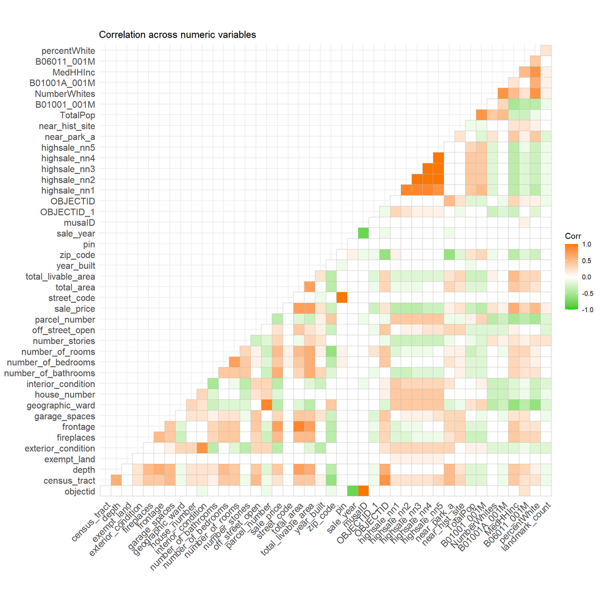

```r
numericVars <-
  select_if(st_drop_geometry(houses), is.numeric) %>% na.omit()

numericVars <- select_if(st_drop_geometry(houses), is.numeric) %>%
  na.omit()


ggcorrplot(
  round(cor(numericVars), 1),
  p.mat = cor_pmat(numericVars),
  colors = c("#25CB10", "white", "#FA7800"),
  type="lower",
  insig = "blank") +
    labs(title = "Correlation across numeric variables")
```

```r
# yet another way to plot the correlation plot using the corrr library
## not working for us
# numericVars %>%
#   correlate() %>%
#   autoplot() +
#   geom_text(aes(label = round(r,digits=2)),size = 2)
```

This correlation matrix helps provide a way to visualize how different numerical variables are related (correlated) to each other in our model. Spatial variables in our model that denote numerical distance like near_hist_site (near a historical site) and near_park_a (near a large park with many amenities) show low correlations. The k-nearest neighbor variables (highsale_nn1-5) which detail the average distance to the k (specified amount of) nearest houses that sold for over $1 million all show a high positive correlation. These highly correlated variables can be used as proxies for each other and only one is necessary for the purposes of this model.

Other notable correlations include: The amount of frontage (the space between road and the building) and the total area have a strong positive correlation, A positive correlation between the house’s exterior and interior conditions, as well as correlations between miscellaneous and redundant variables like geographic ward, parcel number, object id and musaid. While the redundant, database-specific variables would not be considered for the model, this correlation matrix has helped identify how some of our existing and added variables should be minimized to reduce collinearity. Collinearity is when independent variables are correlated and often recognized when two variables have correlation coefficients higher than 0.8 or lower than -0.8. This means that information from the predictor variable is already captured by another used in the model.

### Plotting the Relationship

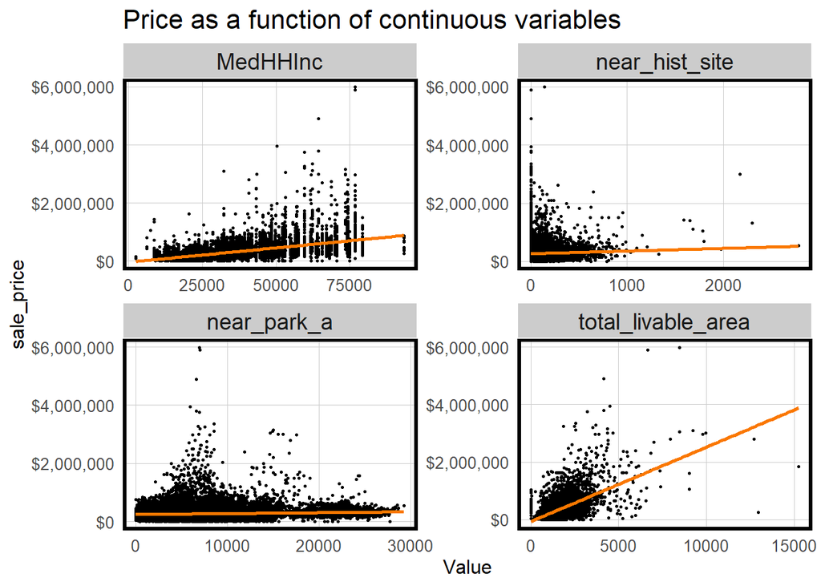

```r
# try ratio of rooms and floors
## Home Features cor
st_drop_geometry(houses) %>%
  dplyr::select(sale_price, near_park_a, near_hist_site, total_livable_area,MedHHInc) %>%
  # filter(sale_price <= 1000000, Age < 500) %>%
  gather(Variable, Value, -sale_price) %>%
   ggplot(aes(Value, sale_price)) +
     geom_point(size = .5) + geom_smooth(method = "lm", se=F, colour = "#FA7800") +
     facet_wrap(~Variable, ncol = 2, scales = "free") +
     labs(title = "Price as a function of continuous variables") +
  scale_y_continuous(labels = scales::dollar_format(prefix = "$"))+
     plotTheme()
```

```r
# see where M's are
# names(houses)[startsWith(names(houses),"m")==TRUE]
# names(houses)[startsWith(names(houses),"M")==TRUE]
#
# table(startsWith(names(houses),"m"))
# table(startsWith(names(houses),"M"))
```

### Mapping House Variables

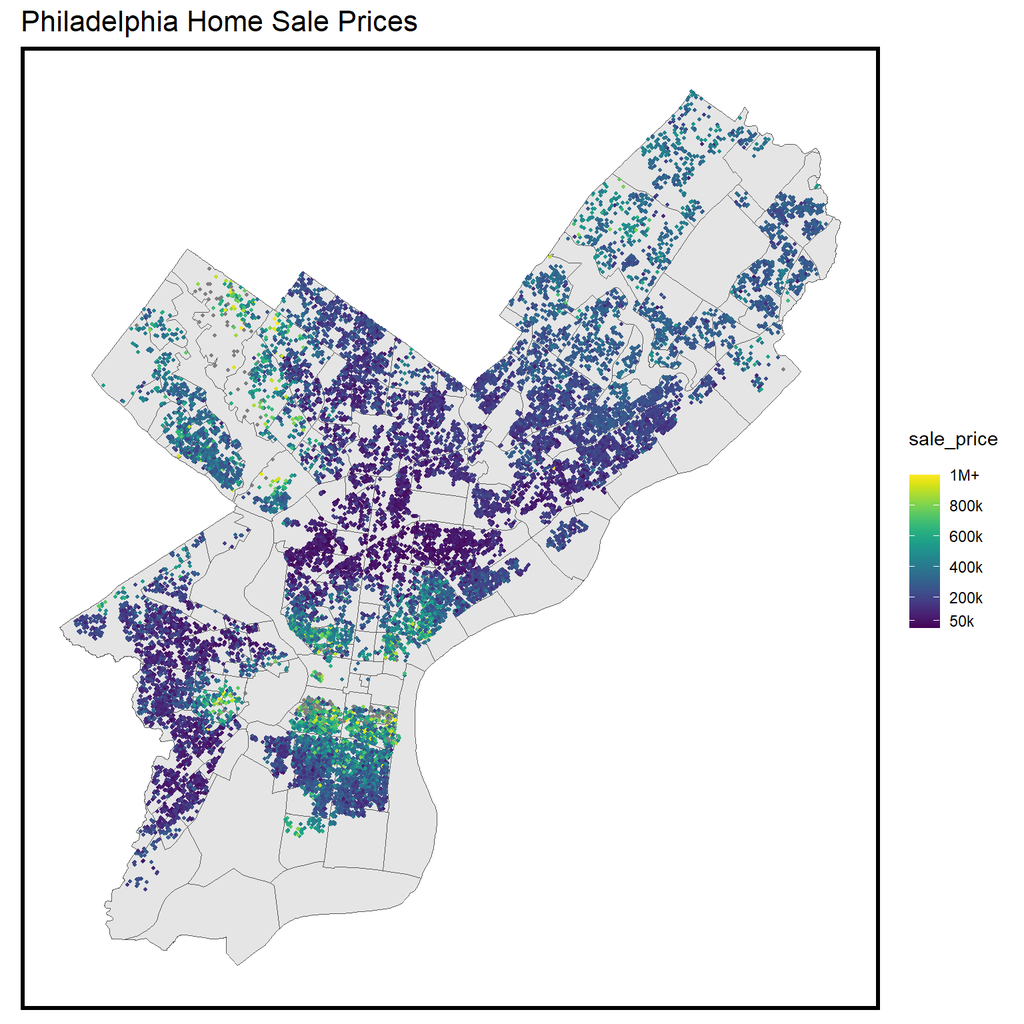

```r
houses_filtered <- houses %>%
  filter(sale_price > 0)

houses_filtered <- houses %>%
  filter(!is.na(sale_price) & sale_price > 0)

# Create the map with filtered data
ggplot() +
  geom_sf(data = nhood, fill = "grey90") +
  geom_sf(data = houses_filtered, aes(colour = sale_price),
          show.legend = "point", size = 0.75) +
  scale_color_viridis(
    limits = c(0, 1000000),  # Set the color scale limits (0 to 1,000,000)
    breaks = c(50000, 200000, 400000, 600000, 800000, 1000000), # Fewer breaks
    labels = c("50k", "200k", "400k", "600k", "800k", "1M+") # Shorter labels
  ) +
  labs(title="Philadelphia Home Sale Prices") +
  mapTheme() +
  theme(
    legend.title = element_text(margin = margin(b = 10)) # Adjust the bottom margin
  )
```

For this model we are testing which variables will affect the home sale price, so home sale price is considered the “dependent variable”. the map shows all the recorded sales prices in Philadelphia ranging from $50,000 to $1,000,000 or more. visually analyzing the map we can see that housing prices tend to cluster. This means that houses that are close to each other are generally similar in prices. One explanation for the clustering of prices can be that the houses have similar proximity to amenities such as parks, attractions and transportation. We will test if those relationships are key indicators of housing prices.

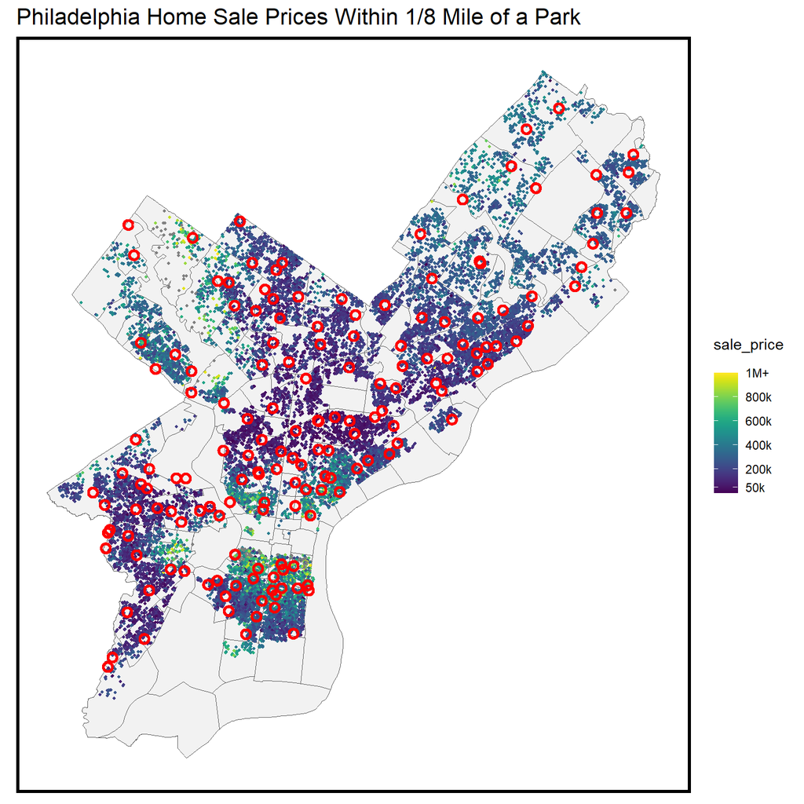

```r
# Create the map with filtered data


ggplot() +
  geom_sf(data = nhood, fill = "grey95") +
  geom_sf(data = houses, aes(colour = sale_price),
          show.legend = "point", size = 0.75) +
  scale_color_viridis(
    limits = c(0, 1000000),  # Set the color scale limits (0 to 1,000,000)
    breaks = c(50000, 200000, 400000, 600000, 800000, 1000000), # Fewer breaks
    labels = c("50k", "200k", "400k", "600k", "800k", "1M+") # Shorter labels
  ) +
  geom_sf(data = parks_buffer, color = "red", fill = "transparent",linewidth=1,show.legend = TRUE, size = 2) +
  labs(title="Philadelphia Home Sale Prices Within 1/8 Mile of a Park") +
  mapTheme() +
  theme(
    legend.title = element_text(margin = margin(b = 10)) # Adjust the bottom margin
  )
```

This map explores if there is a relationship between access to parks and recreational facilities and home sales price in Philadelphia. In this map access is defined as a walkable distance of 1/8 mile to or from a park or recreational facility. Analyzing the map we can see that there is an even distribution of parks throughout the city, especially in neighborhoods with higher concentrations of housing. in some instances in the northeast and northwest where there are less parks and recreation facilities there are larger concentrations of homes with higher sales prices.

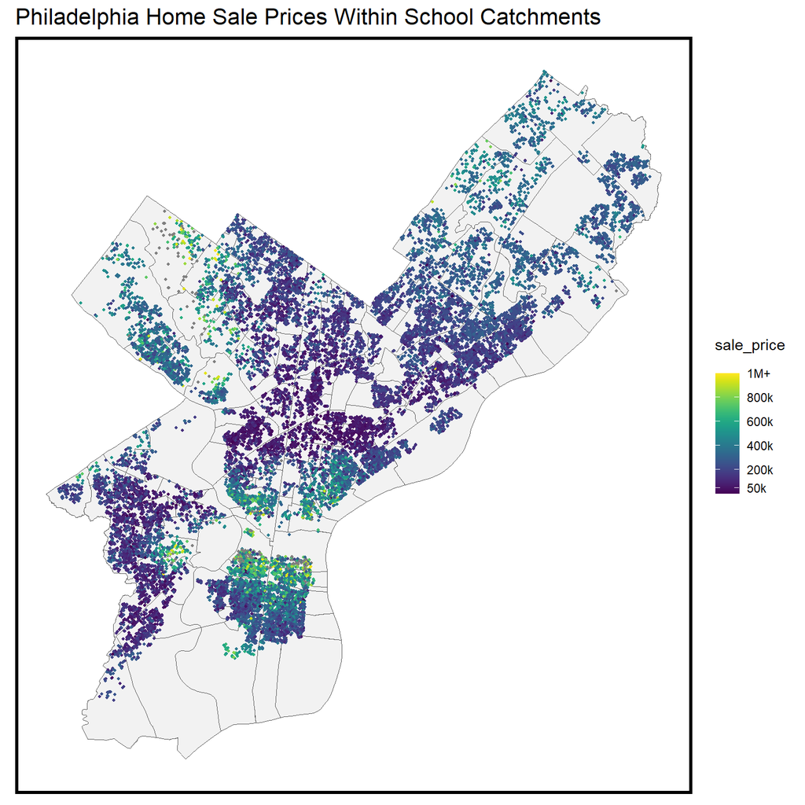

```r
ggplot() +
  geom_sf(data = school_catch, aes(), show.legend = FALSE, alpha = 0.5) +  # Create an empty layer for school_catch
  geom_sf(data = houses, aes(colour = sale_price),
          show.legend = "point", size = 0.75) +
  scale_color_viridis(
    limits = c(0, 1000000),  # Set the color scale limits (0 to 1,000,000)
    breaks = c(50000, 200000, 400000, 600000, 800000, 1000000), # Fewer breaks
    labels = c("50k", "200k", "400k", "600k", "800k", "1M+") # Shorter labels
  ) +
  labs(title="Philadelphia Home Sale Prices Within School Catchments") +
  mapTheme() +
  theme(
    legend.title = element_text(margin = margin(b = 10)) # Adjust the bottom margin
  )
```

This map explores the relationship between home sales price and the school catchment that the home is located in. School catchments are essentially geographical boundaries that determine which public school a child can attend based on their home address. This can affect home prices because catchments with better schools will create a greater living demand which could drive up home process. Based on visual examination of the map we can see that there is clustering of home price sales in the individual catchments. This means that the catchment for which the home is in can have an affect on home sale price.

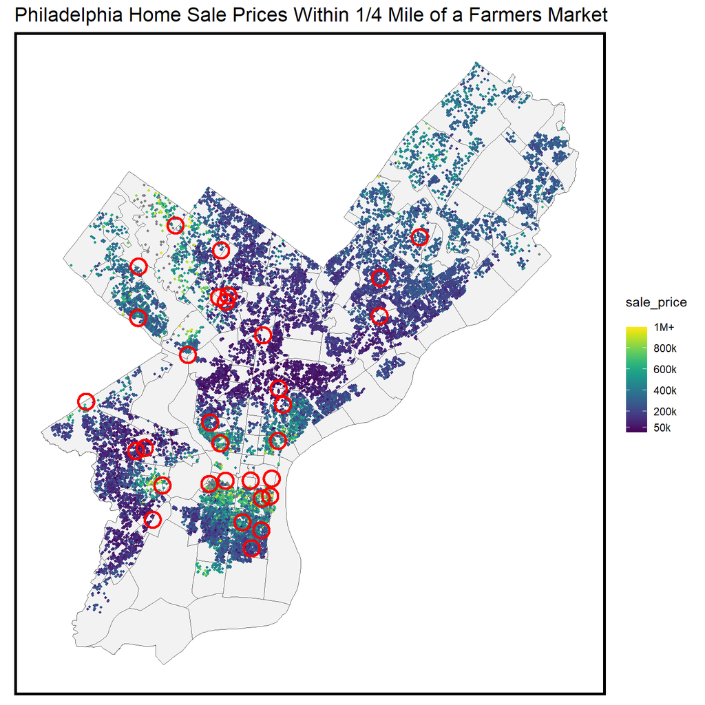

```r
farmers_buffer <- st_buffer(farmers_market, dist = 1320)
# Create the map with filtered data
ggplot() +
  geom_sf(data = nhood, fill = "grey95") +
  geom_sf(data = houses, aes(colour = sale_price),
          show.legend = "point", size = 0.75) +
  scale_color_viridis(
    limits = c(0, 1000000),  # Set the color scale limits (0 to 1,000,000)
    breaks = c(50000, 200000, 400000, 600000, 800000, 1000000), # Fewer breaks
    labels = c("50k", "200k", "400k", "600k", "800k", "1M+") # Shorter labels
  ) +
  geom_sf(data = farmers_buffer, color = "red", fill = "transparent",linewidth=1,show.legend = TRUE, size = 2) +
  labs(title="Philadelphia Home Sale Prices Within 1/4 Mile of a Farmers Market") +
  mapTheme() +
  theme(
    legend.title = element_text(margin = margin(b = 10)) # Adjust the bottom margin
  )
```

# Methods

Following the collection and exploration of pre-existing and additional data, we are ready to begin the formation of our linear model and gauging its effectiveness.

This process begins with splitting our set of 23,781 houses into a training set used to build our linear fit model and a testing set which will be predicted upon. We choose to make our training set 80% of our data due for two main reasons. First, our decision to include housing records with extremely large or low sales prices such as those with sales prices of $0 and $5,990,000 would have strong effects on a linear model, but some details about Philadelphia at the time of purchase could be captured in those prices. Having more training data will ideally lower the adverse effects on the prediction model while still giving a portion of the relationships that are difficult for people to see. Secondly, the 80% training to 20% testing split is an often accepting starting point for model evaluation especially given our data size of 23,781 houses.

After splitting our data, the `lm` function is used to create our linear model with respect to our previously discussed variables–both internal home characteristics and spatial ones. The accuracy is them measured by …

1. Predicting the sales price of homes in the testing set
2. Finding the absolute error between predicted and observed sales prices as dollar values and percents
3. Performing a k-fold cross validation that performs steps 1 & 2 again with smaller, different validation sets 100 times and returns accuracy metrics
4. Showing the mean errors of the model predictions visually with maps and scatter plots
5. Testing generalizability of the model with respect to racial and income contexts.

# Results

With the completion of our methods, we can observe our model’s accuracy and proposed correlation of variables with sale price as seen with the following tables below. The first showcases the linear model summary created from the training set. Many variables are categorical; therefore, there is a comparison element for sales prices with the default being the main focus of discussion here. The second simply displays the mean absolute percent error (MAPE) and mean absolute error (MAE) between the predicted sales price and observed sales price for all houses in the testing set. The first value is a percentage while the second is in dollars.

```r
# split
modelling <- houses[houses$toPredict=="MODELLING",]
challenge <- houses[houses$toPredict!="MODELLING",]

inTrain <- createDataPartition(
              y = paste(modelling$parcel_shape, modelling$quality_grade, modelling$near_park_of_class, modelling$p_district,
                        modelling$near_uni, modelling$near_fmarket, modelling$has_landmark, modelling$high_income,
                        modelling$catch_name,  modelling$near_park_a, modelling$near_hist_site, modelling$neighborhood, modelling$raceContext, modelling$incomeContext
                        ),
              p = .80, list = FALSE)
houses.train <- modelling[inTrain,]
houses.test <- modelling[-inTrain,]

# get mode and fill testing columns
houses.training <-
  lm(sale_price ~ ., data = as.data.frame(houses.train)%>%
       # !! put final variable list in select() !!
       dplyr::select(sale_price,near_park_of_class,neighborhood,catch_name,high_income,landmark_count,near_fmarket,near_uni,number_of_bedrooms, total_area,fireplaces,total_livable_area,MedHHInc,near_park_a))
                      # removed
                      ## p_district
                      ## year_built, number_of_bathrooms, number_of_rooms, number_stories

houses.test <-
  houses.test %>%
  dplyr::mutate(Regression = "Baseline Regression",
         SalePrice.Predict = predict(houses.training, houses.test),
         SalePrice.Error = SalePrice.Predict - sale_price,
         SalePrice.AbsError = abs(SalePrice.Predict - sale_price),
         SalePrice.APE = (abs(SalePrice.Predict - sale_price)) / sale_price)


# table of training set summary
# summary(houses.training) indices (1:12), important noted
## 3 = residuals
## 4 = coefficients
## 5 = aliased
## 6 = sigma
## 7 = df
## 8 = r.squared
## 9 = adj.r.squared
# coef<-summary(houses.training)[4]
# r2 <- summary(houses.training)[8]
# r2_adj <- summary(houses.training)[9]

require(memisc)
options(summary.stats.lm=c('Coefficients','R-squared','Adjusted R-squared'))
memisc::mtable('Model 1' = houses.training)
```

```
##
## Calls:
## Model 1: lm(formula = sale_price ~ ., data = as.data.frame(houses.train) %>%
##     dplyr::select(sale_price, near_park_of_class, neighborhood,
##         catch_name, high_income, landmark_count, near_fmarket,
##         near_uni, number_of_bedrooms, total_area, fireplaces,
##         total_livable_area, MedHHInc, near_park_a))
##
## ==================================================================================================
##   (Intercept)                                                                      253241.660***
##                                                                                    (47945.405)
##   near_park_of_class: B/A                                                           12962.738
##                                                                                    (34664.667)
##   near_park_of_class: C/A                                                            6956.908
##                                                                                    (72819.987)
##   near_park_of_class: no_park/A                                                    -10105.826
##                                                                                    (28383.520)
##   near_park_of_class: S/A                                                            1370.396
##                                                                                    (31803.591)
##   neighborhood: FAIRMOUNT/CHESTNUT_HILL                                           -173603.994***
##                                                                                    (35865.266)
##   neighborhood: FISHTOWN/CHESTNUT_HILL                                            -231645.149***
##                                                                                    (36340.634)
##   neighborhood: FITLER_SQUARE/CHESTNUT_HILL                                       -162985.965***
##                                                                                    (39683.071)
##   neighborhood: GRADUATE_HOSPITAL/CHESTNUT_HILL                                   -188103.242***
##                                                                                    (36539.244)
##   neighborhood: MANAYUNK/CHESTNUT_HILL                                            -235727.377***
##                                                                                    (35797.546)
##   neighborhood: NORTHERN_LIBERTIES/CHESTNUT_HILL                                  -167538.477***
##                                                                                    (38073.683)
##   neighborhood: Other/CHESTNUT_HILL                                               -226477.455***
##                                                                                    (33859.327)
##   neighborhood: SOCIETY_HILL/CHESTNUT_HILL                                          87812.707
##                                                                                   (138777.090)
##   neighborhood: WASHINGTON_SQUARE/CHESTNUT_HILL                                      4570.687
##                                                                                   (138867.170)
##   catch_name: Allen, Ethan/Adaire, Alexander                                      -157009.095***
##                                                                                    (17539.546)
##   catch_name: Allen, Ethel D/Adaire, Alexander                                    -257987.607***
```

[output cut: 324 more lines]

```
##                                                                                      (784.021)
##   total_area                                                                            0.702*
##                                                                                        (0.285)
##   fireplaces                                                                        50254.640***
##                                                                                     (3558.907)
##   total_livable_area                                                                  203.191***
##                                                                                        (2.069)
##   MedHHInc                                                                              1.870***
##                                                                                        (0.165)
##   near_park_a                                                                           3.448***
##                                                                                        (0.748)
## --------------------------------------------------------------------------------------------------
##   R-squared                                                                             0.686
## ==================================================================================================
##   Significance: *** = p < 0.001; ** = p < 0.01; * = p < 0.05
```

```r
# table of testing set MAE (NEED MAPE too)
st_drop_geometry(houses.test)%>%
  dplyr::select(SalePrice.APE,SalePrice.AbsError)%>%
  summarize(MAPE = mean(SalePrice.APE,na.rm=T), MAE = mean(SalePrice.AbsError,na.rm=T))%>%
  gather(Variable, Value) %>%
  mutate(Value = ifelse(Value<1,round(Value*100, 0),round(Value,0))) %>%
  kable(caption="Accuracy Metrics of Linear Model",
        col.names = c("Metric Name","Metric Value"))%>%
    kable_styling(bootstrap_options = "striped", full_width = F, position = "left")
```

Accuracy Metrics of Linear Model

| Metric Name | Metric Value |
| --- | --- |
| MAPE | 56 |
| MAE | 140568 |

In regards to predictions on the testing set, there is a mean difference of $140,567.69 dollars between the predicted sales price and the observed price corresponding to an average difference of ≈56%. A variety of factors could contribute to this and encourage additional modifications to the model’s design.

To test the accuracy of our model the datasets are randomly split into *training data* and *testing data*. The training data is used to train a model to make sales predictions and the testing data is used to test the accuracy of the model. After running the regression analysis testing the accuracy of the model, we are given the results in the forms of intercepts, coefficients, R-Squared, and Adjusted R-Squared.

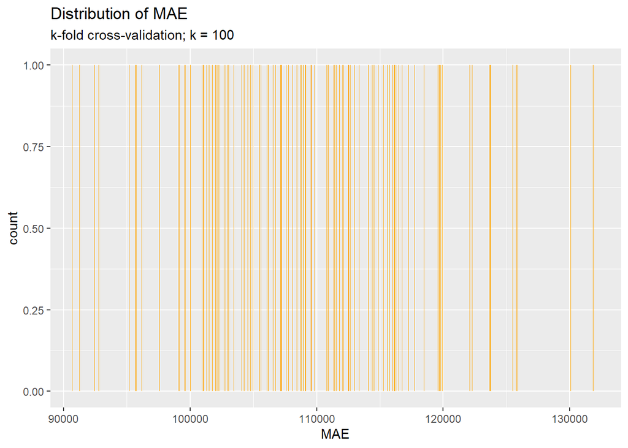

```r
# set.seed(888)
reg.cv <-
  train(sale_price ~ .,data=st_drop_geometry(houses.train)%>%
          # !! put final variable list in select() !!
          dplyr::select(sale_price,p_district,near_park_of_class),
        method = "lm",
        trControl = trainControl(method="cv",number=100),
        na.action = na.pass)
# set.seed(NULL)

# see average MAE:
sprintf("The average MAE: $%f",reg.cv$results[4])
sprintf("The standard deviation in MAE: $%f",reg.cv$results[7])

# see vector of MAE for each fold:
ggplot(data = reg.cv$resample[1:nrow(reg.cv$resample),])+
  geom_bar(aes(x=MAE),stat="count",fill="orange",width=40)+
     labs(title = "Distribution of MAE",
          subtitle = "k-fold cross-validation; k = 100",
          xlab("Mean Absolute Error"))+
  coord_cartesian(xlim = c(round(min(reg.cv$resample[3]),-3), round(max(reg.cv$resample[3]),-3)))
```

```r
     plotTheme()
```

The above histogram displays the frequency of specific MAE’s across the 100 folds in our k-fold cross validation. Interestingly enough, each fold had a unique mean absolute error as shown with each bar having a height of 1.

Using 100-fold cross validation, the accuracy slightly improves with an average MAE of $109,303.90 across all 100 folds. For any randomly chosen fold of the 100, you can expect the MAE to fall within a $8,713.23 range above or below the average MAE. These k-fold validations using smaller subsets of training and testing sets give the impression that the model is fairly generalizable with an improved MAE when compared to the single set testing set discussed earlier.

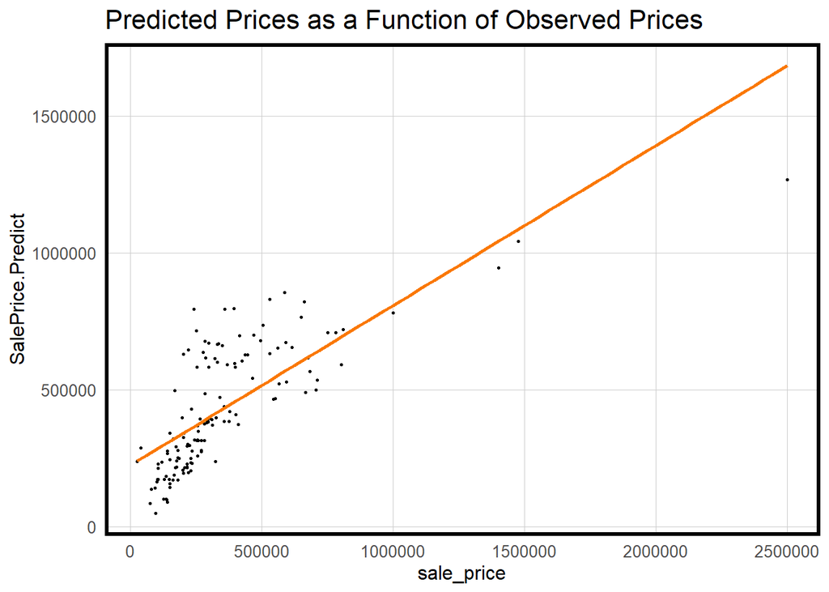

```r
st_drop_geometry(houses.test) %>%
  dplyr::select(sale_price, SalePrice.Predict) %>%
  # filter(sale_price <= 1000000, Age < 500) %>%
   ggplot(aes(sale_price, SalePrice.Predict)) +
     geom_point(size = .5) + geom_smooth(method = "lm", se=F, colour = "#FA7800") +
     labs(title = "Predicted Prices as a Function of Observed Prices") +
     plotTheme()
```

The above scatterplot gives an alternate look at the predicted prices compared to observed sales prices. Looking here, we can see that the linear model appears to overestimate more homes than it underestimates though homes priced from $750,000 to $1,500,000 are much closer to the prediction line than houses outside of that range.

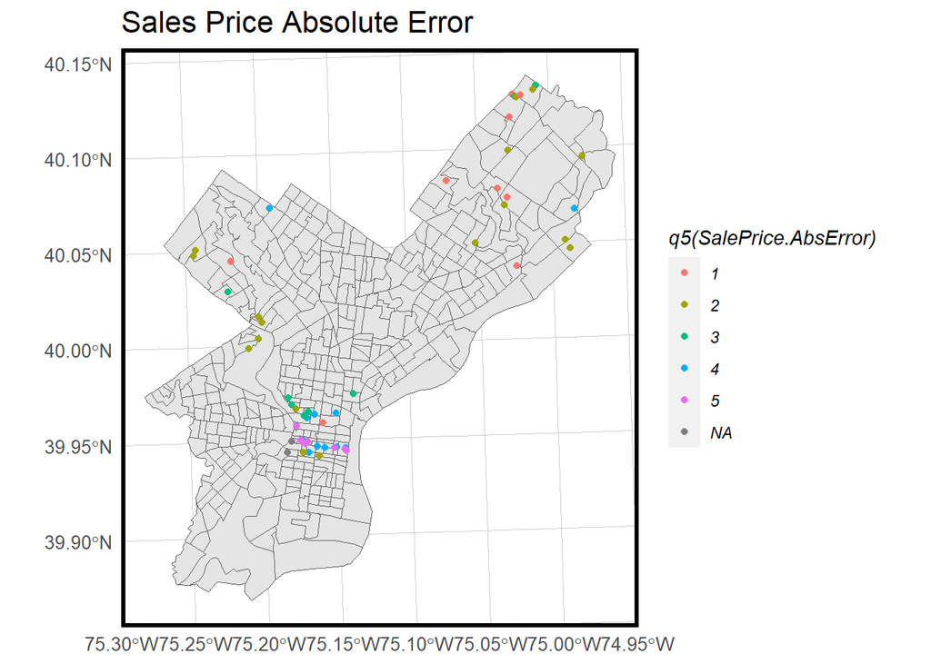

```r
# map of residuals
houses.test%>% dplyr::select(SalePrice.AbsError,geometry)%>%
  ggplot() +
    geom_sf(data=tracts20)+
    geom_sf(aes(color = q5(SalePrice.AbsError)))+
    labs(title = "Sales Price Absolute Error") +
    scale_fill_viridis(discrete=TRUE)+
    scale_fill_manual(values= palette5,
                      labels = qBr(houses.test%>% dplyr::select(SalePrice.AbsError,geometry), "SalePrice.AbsError"),
                      name = "Absolute Error in Prediction\n(Quintile Breaks)")+
    plotTheme()
```

This map of houses in the testing set by the Absolute Error in Price Predictions shows that the model is fairly more accurate in areas further from Center City due to more homes in quantile 1 ($3,504 or less away from the actual price) being observed. The homes near center city have a larger variation in absolute errors with at least one home in every quantile and at least five whose absolute error ranges from $107,729 to $230,203.40.

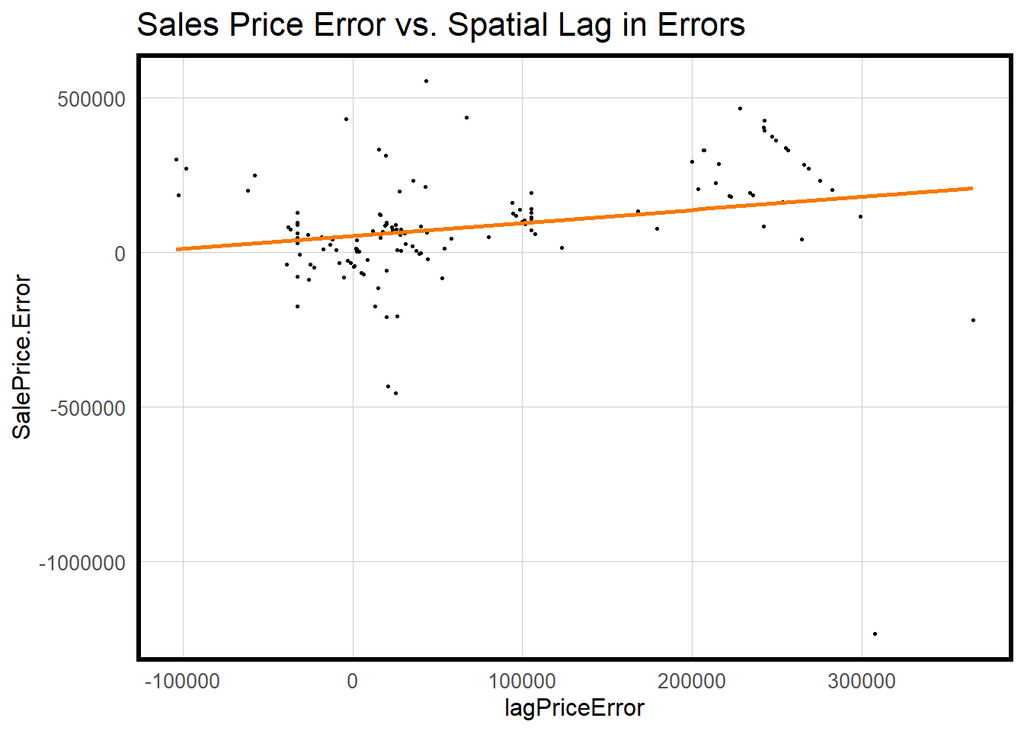

```r
# moran's I setup (likely used in residuals and plot too)
coords<- st_coordinates(houses)
neighborList<-knn2nb(knearneigh(coords,5))
spatialWeights<-nb2listw(neighborList,style="W")

coords.test<- st_coordinates(houses.test)
neighborList.test<-knn2nb(knearneigh(coords.test,5))
spatialWeights.test<-nb2listw(neighborList.test,style="W")

houses.test %>%
  mutate(lagPriceError = lag.listw(spatialWeights.test,
                                   replace_na(SalePrice.Error,mean(SalePrice.Error,na.rm=T))))%>%
  ggplot(aes(lagPriceError, SalePrice.Error))+
  geom_point(size = .5) + geom_smooth(method = "lm", se=F, colour = "#FA7800") +
     labs(title = "Sales Price Error vs. Spatial Lag in Errors") +
     plotTheme()
```

This plot shows the error in sales price prediction for a single home compared to the average weighted error of the 5 homes closest too it–referred to as the spatial lag in the errors. It communicates that the more the model overestimates, the trend of overestimation happens consistently across all homes in the area. This conclusion can be drawn despite the existence of a few home prices that the model severely underestimates (by $1M in one case) while nearby homes are overestimated.

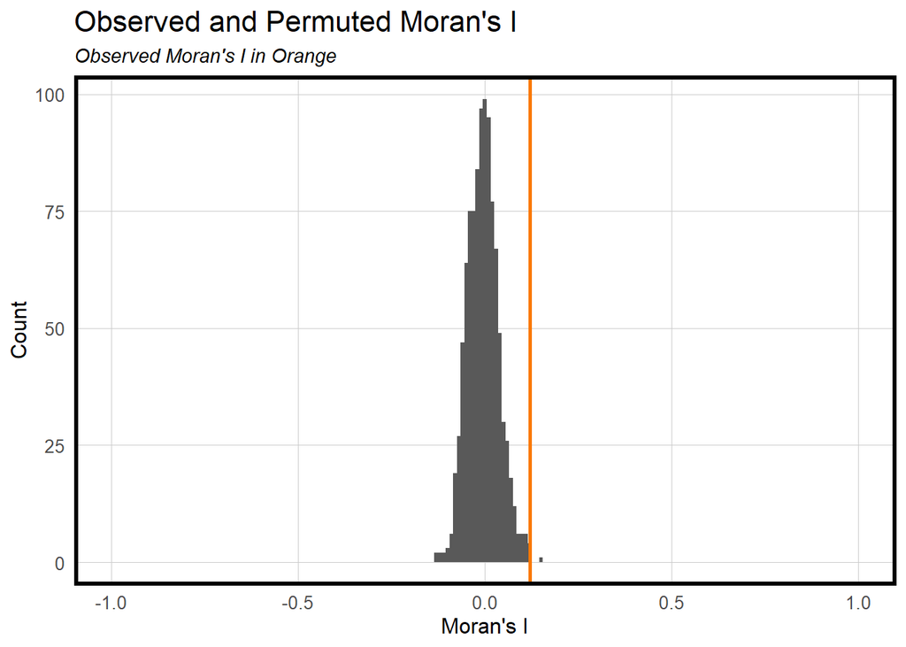

```r
## start moran's
moranSim <- moran.mc(replace_na(houses.test$SalePrice.Error,mean(houses.test$SalePrice.Error,na.rm=T)),
                     spatialWeights.test, nsim = 999)

# moran's hist and statistic vline
ggplot(as.data.frame(moranSim$res[c(1:999)]),
       aes(moranSim$res[c(1:999)])) +
  geom_histogram(binwidth = 0.01)+
  geom_vline(aes(xintercept=moranSim$statistic),
             color = "#FA7800",size=1)+
  scale_x_continuous(limits = c(-1,1))+
  labs(title="Observed and Permuted Moran's I",
       subtitle="Observed Moran's I in Orange",
       x="Moran's I",
       y="Count")+
  plotTheme()
```

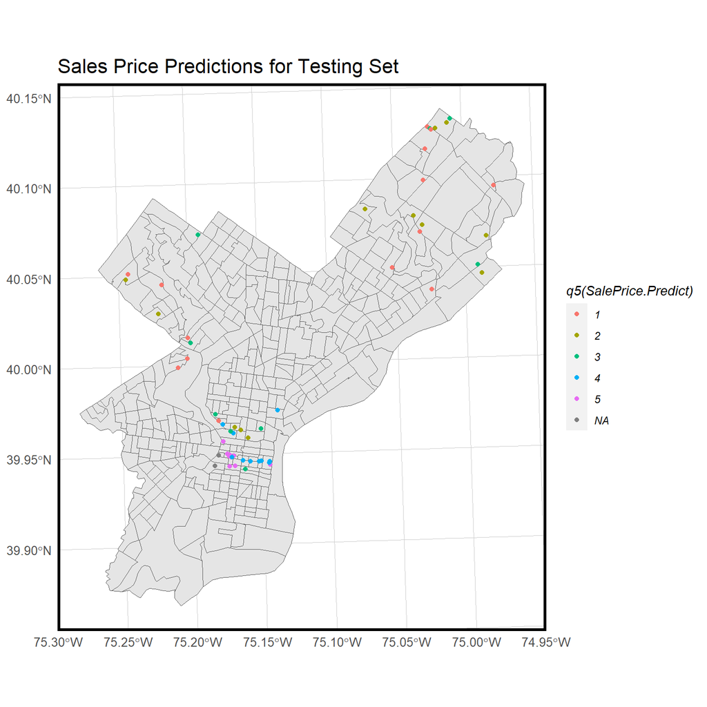

```r
# map of predicted values
houses.test%>% dplyr::select(SalePrice.Predict,geometry)%>%
  ggplot() +
    geom_sf(data=tracts20)+
    geom_sf(aes(color = q5(SalePrice.Predict)))+
    labs(title = "Sales Price Predictions for Testing Set") +
    scale_fill_viridis(discrete=TRUE)+
    scale_fill_manual(values= palette5,
                      labels = qBr(houses.test%>% dplyr::select(SalePrice.Predict,geometry), "SalePrice.Predict"),
                      name = "House Price Prediction\n(Quintile Breaks)")+
    plotTheme()
```

This map shows the predictions of home prices divided into 5 groups.

1. < ≈$90,000 - red
2. ≈$90,000 to $220,000 - gold
3. ≈$220,000 to $300,000 - green
4. ≈$300,000 to $450,000 - blue
5. > ≈$450,000 - purple

Like with the absolute errors, the most variation between groups is near Center City and the lowest predicted prices are near the edges of the county like Manayunk and Northeast Philadelphia.

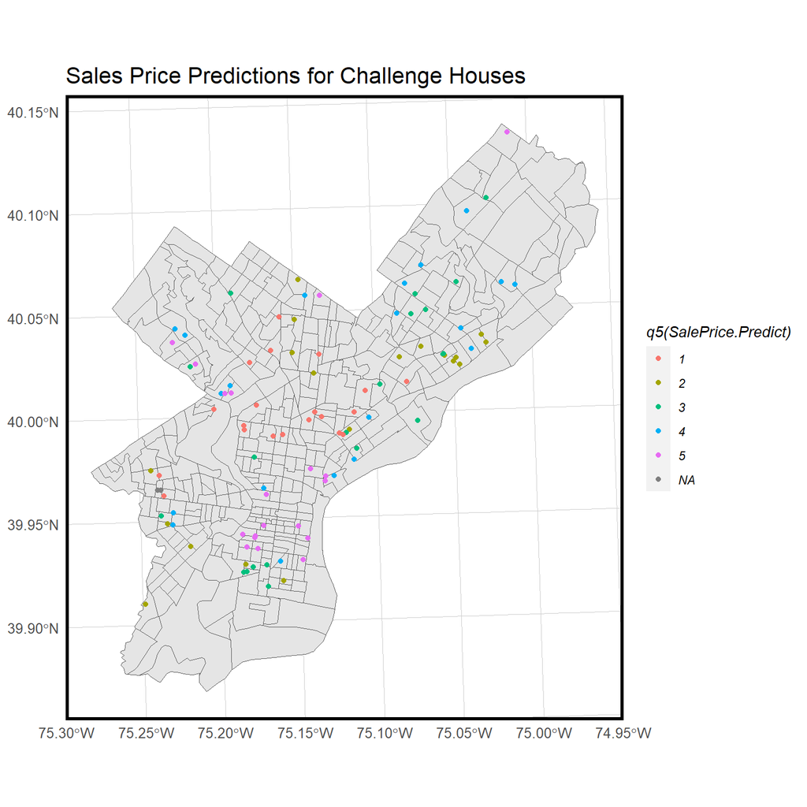

```r
# a little preprocessing for challenge houses
challenge.test <-
  challenge %>%
  mutate(Regression = "Baseline Regression",
         SalePrice.Predict = predict(houses.training, challenge),
         SalePrice.Error = SalePrice.Predict - sale_price,
         SalePrice.AbsError = abs(SalePrice.Predict - sale_price),
         SalePrice.APE = (abs(SalePrice.Predict - sale_price)) / sale_price)

# challenge map
challenge.test%>% dplyr::select(SalePrice.Predict,geometry)%>%
  ggplot() +
    geom_sf(data=tracts20)+
    geom_sf(aes(color = q5(SalePrice.Predict)))+
    labs(title = "Sales Price Predictions for Challenge Houses") +
    scale_fill_viridis(discrete=TRUE)+
    scale_fill_manual(values= palette5,
                      labels = qBr(challenge.test%>% dplyr::select(SalePrice.Predict,geometry), "SalePrice.Predict"),
                      name = "House Price Prediction\n(Quintile Breaks)")+
    plotTheme()
```

The map for the predictions of home prices in the challenge group has altered divisions.

1. < ≈$27,000 - red
2. ≈$27,000 to $125,000 - gold
3. ≈$125,000 to $200,000 - green
4. ≈$200,000 to $260,000 - blue
5. > ≈$260,000 - purple

Here, North Philadelphia and West Philadelphia had the lower predicted prices. The most expensive predictions were once again located in center city, though The far Northeast and Manayunk had a few predicted at above $260,000 and the rest were only a step lower in these areas.

### Showing Accuracy across Planning Districts

Next, we looked at accuracy by areal units as opposed to single points as seen with the following maps and plots.

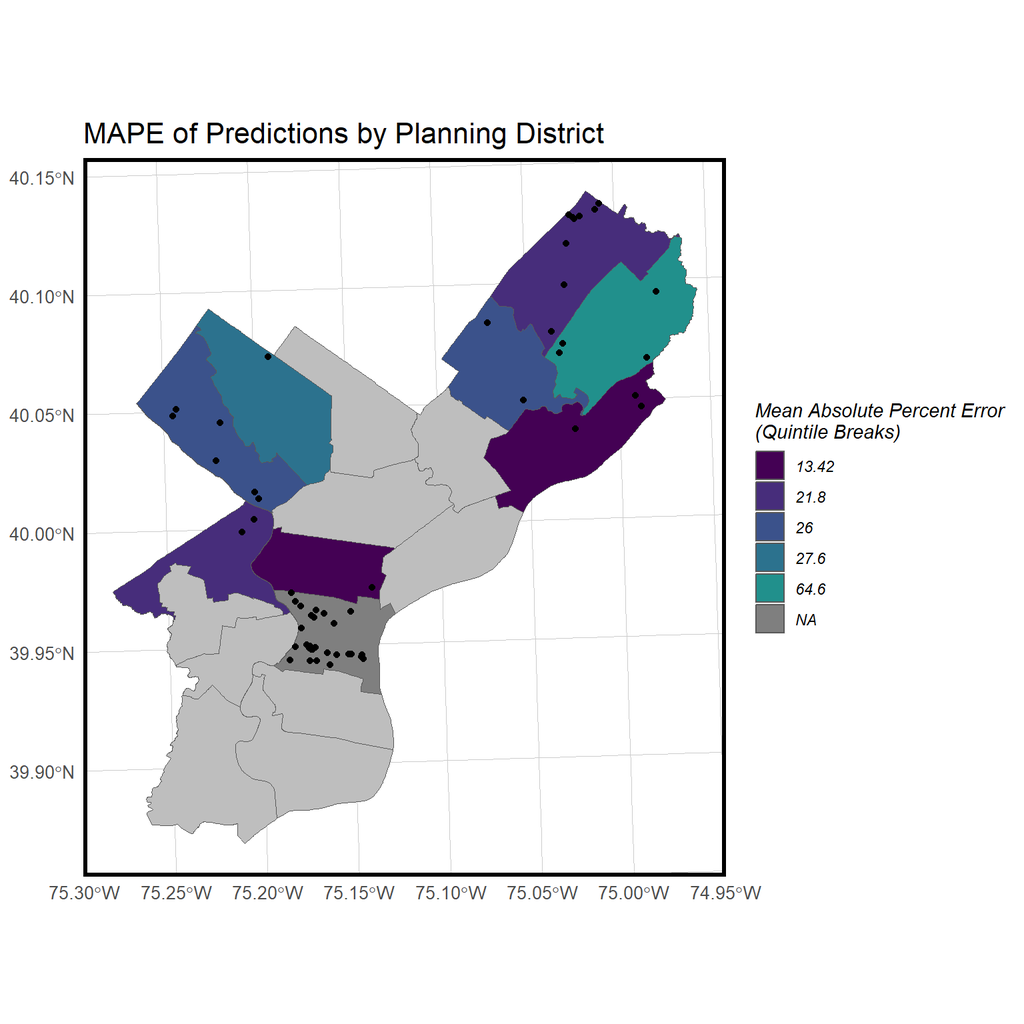

```r
# get mean ape in neighborhood?
# map of MAPE
forMap<-
  st_drop_geometry(houses.test)%>% dplyr::select(SalePrice.APE,p_district,neighborhood)%>%
  group_by(p_district)%>%
  summarize(MAPE = mean(SalePrice.APE))%>%
  ungroup()%>%
  left_join(planning_dist%>%dplyr::rename(p_district = DIST_NAME))%>%
  st_sf()%>%
  dplyr::mutate(readMAPE=MAPE*100)


forMap%>%
  ggplot() +
  geom_sf(data=planning_dist,fill = "gray")+
    geom_sf(aes(fill = as.factor(ntile(MAPE,5))))+
    geom_sf(data=houses.test,color="black",size=1.5)+
    labs(title = "MAPE of Predictions by Planning District") +
    scale_fill_viridis(discrete=TRUE)+
    scale_fill_manual(values= palette9,
                      labels = as.character(as.numeric(qBr(forMap,"readMAPE"))),
                      name = "Mean Absolute Percent Error\n(Quintile Breaks)")+
    plotTheme()
```

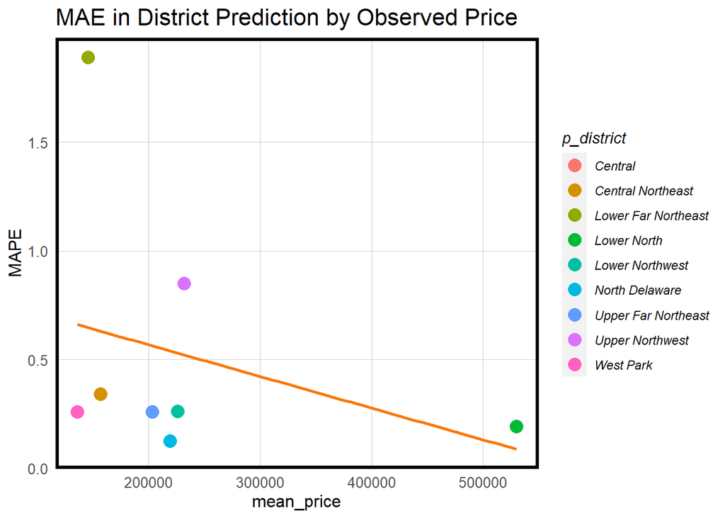

```r
# get mean ape in neighborhood?
# scatter plot of MAPE/mean price
houses.test%>% dplyr::select(SalePrice.APE,sale_price,p_district,neighborhood,geometry)%>%
  group_by(p_district)%>%
  summarize(MAPE = mean(SalePrice.APE),
            mean_price = mean(sale_price))%>%
  ggplot(aes(mean_price, MAPE)) +
     geom_point(size = 4, aes(color = p_district)) + geom_smooth(method = "lm", se=F, colour = "#FA7800") +
     labs(title = "MAE in District Prediction by Observed Price") +
     plotTheme()
```

This map showing the MAE of the planning districts’ sales price predictions as a function of their mean price communicates that the amount of error decreases as the mean price within the planning district goes up. Considering an earlier scatter plot on predicted to observed prices, the mean prices shown here hit the lower quarter of the observed prices where the model overestimated before reaching the $750,000 to $1,500,000 region of relatively accurate predictions.

## Considering Generalizability Through Race and Income

The American Community Survey’s 2016-2020 data was used to split our study area of Philadelphia into majority white and majority non-white areas as seen in the `Race Context` map below and high income versus low income areas as seen in the `Income Context` map below.

*For reference, high income is denoted by regions where the majority of the population make more than $31,379.48 a year (the average median income for all Philadelphia county census tracts for 2020.*

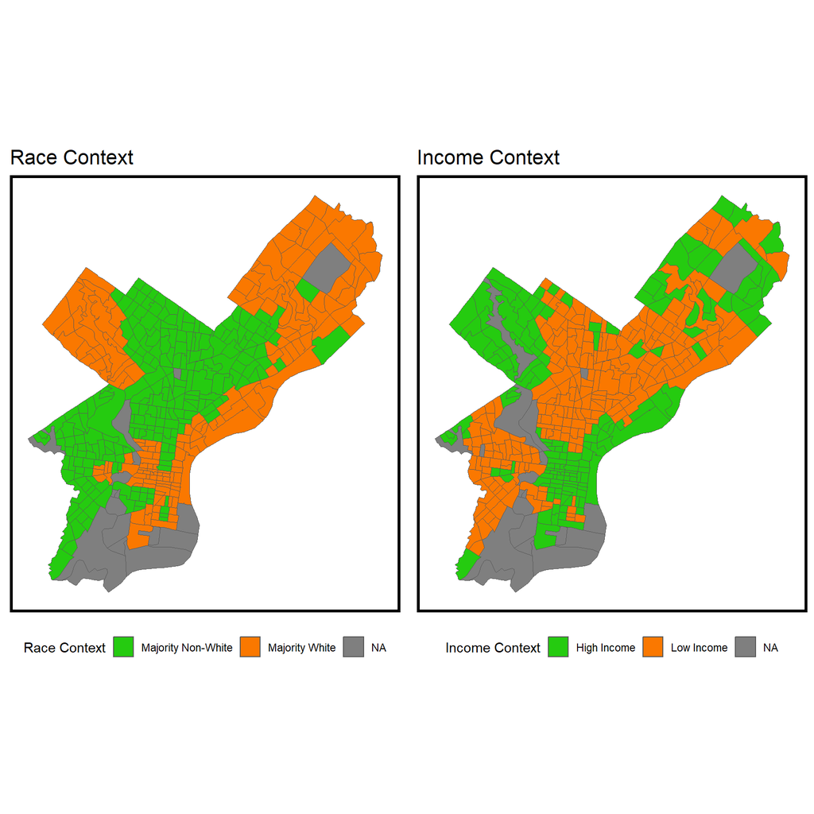

```r
grid.arrange(ncol = 2,
  ggplot() + geom_sf(data = tracts20, aes(fill = raceContext)) +
    scale_fill_manual(values = c("#25CB10", "#FA7800"), name="Race Context") +
    labs(title = "Race Context") +
    mapTheme() + theme(legend.position="bottom"),
  ggplot() + geom_sf(data = tracts20, aes(fill = incomeContext)) +
    scale_fill_manual(values = c("#25CB10", "#FA7800"), name="Income Context") +
    labs(title = "Income Context") +
    mapTheme() + theme(legend.position="bottom"))
```

```r
# for race context
left_join(
  st_drop_geometry(houses.test)%>%
    group_by(raceContext)%>%
    summarize(meanPrice_Race = round(mean(sale_price,na.rm=T),1)),
  mutate(houses.test,predict.re =
           predict(lm(sale_price~raceContext,data=houses.test),houses.test))%>%
    st_drop_geometry%>%
    group_by(raceContext)%>%
    summarize(meanPrediction_Race = round(mean(predict.re),1)))%>%
  kable(col.names=c("Race Context", "Mean Price","Mean Prediction"))%>%kable_styling()
```

| Race Context | Mean Price | Mean Prediction |
| --- | --- | --- |
| Majority Non-White | 158619.7 | 158619.7 |
| Majority White | 374271.7 | 374271.7 |

```r
# for income context
left_join(
  st_drop_geometry(houses.test)%>%
    group_by(incomeContext)%>%
    summarize(meanPrice_Income = mean(sale_price,na.rm=T)),
  mutate(houses.test,predict.ie =
           predict(lm(sale_price~incomeContext,data=houses.test),houses.test))%>%
    st_drop_geometry%>%
    group_by(incomeContext)%>%
    summarize(meanPrediction_Income = mean(predict.ie)))%>%
  kable(col.names=c("Income Context", "Mean Price","Mean Prediction"))%>%kable_styling()
```

| Income Context | Mean Price | Mean Prediction |
| --- | --- | --- |
| High Income | 367363.9 | 367363.9 |
| Low Income | 177401.2 | 177401.2 |

```r
reg.race<-
  lm(sale_price ~ ., data = as.data.frame(houses.train)%>%
       # !! put final variable list in select() !!
       dplyr::select(sale_price,near_park_of_class,neighborhood,catch_name,high_income,landmark_count,near_fmarket,near_uni,number_of_bedrooms, total_area,fireplaces,total_livable_area,MedHHInc,near_park_a,raceContext))

race.test <-
  houses.test %>%
  dplyr::mutate(Regression = "Race Effects",
         SalePrice.Predict = predict(reg.race, houses.test),
         SalePrice.Error = SalePrice.Predict - sale_price,
         SalePrice.AbsError = abs(SalePrice.Predict - sale_price),
         SalePrice.APE = (abs(SalePrice.Predict - sale_price)) / sale_price)

reg.income<-
  lm(sale_price ~ ., data = as.data.frame(houses.train)%>%
       # !! put final variable list in select() !!
       dplyr::select(sale_price,near_park_of_class,neighborhood,catch_name,high_income,landmark_count,near_fmarket,near_uni,number_of_bedrooms, total_area,fireplaces,total_livable_area,MedHHInc,near_park_a,incomeContext))

income.test <-
  houses.test %>%
  dplyr::mutate(Regression = "Income Effects",
         SalePrice.Predict = predict(reg.income, houses.test),
         SalePrice.Error = SalePrice.Predict - sale_price,
         SalePrice.AbsError = abs(SalePrice.Predict - sale_price),
         SalePrice.APE = (abs(SalePrice.Predict - sale_price)) / sale_price)
```

The mean prices for majority white areas and high income areas being higher just above $350,000 agrees with the division of these areas in both the context maps and in previous prediction maps where higher priced houses–both in prediction and observed price–were located in areas like Central City, the far Northeast, and Manayunk areas. Meanwhile, the majority non-white and low income areas have similar mean prices as well despite their different spatial locations. Irrespective of space, it is possible that one context could be used for another should Zillow try to predict for areas with widely different cultures under one model.

```r
allRegressions <-
  rbind(
    dplyr::select(houses.test, starts_with("SalePrice"), Regression, raceContext, incomeContext) %>%
      mutate(lagPriceError = lag.listw(spatialWeights.test, replace_na(SalePrice.Error,mean(SalePrice.Error,na.rm=T)))),
    dplyr::select(race.test, starts_with("SalePrice"), Regression, raceContext, incomeContext) %>%
      mutate(lagPriceError = lag.listw(spatialWeights.test, replace_na(SalePrice.Error,mean(SalePrice.Error,na.rm=T)))),
    dplyr::select(income.test, starts_with("SalePrice"), Regression, raceContext, incomeContext) %>%
      mutate(lagPriceError = lag.listw(spatialWeights.test, replace_na(SalePrice.Error,mean(SalePrice.Error,na.rm=T)))))

# show table of error metrics
st_drop_geometry(allRegressions) %>%
  gather(Variable, Value, -Regression, -incomeContext, -raceContext) %>%
  filter(Variable == "SalePrice.AbsError" | Variable == "SalePrice.APE") %>%
  group_by(Regression, Variable) %>%
    summarize(meanValue = mean(ifelse(Value<1,round(Value*100, 0),round(Value,0)), na.rm = T)) %>%
    spread(Variable, meanValue) %>%
    kable(col.names=c("Income Context","Absolute Error ($)","APE (%)"))%>%kable_styling()
```

| Income Context | Absolute Error ($) | APE (%) |
| --- | --- | --- |
| Baseline Regression | 140567.7 | 28.11429 |
| Income Effects | 140419.3 | 28.68571 |
| Race Effects | 140704.6 | 27.41429 |

```r
submit<-challenge.test[c("musaID","SalePrice.Predict")] %>%
  st_drop_geometry %>%
  dplyr::rename(prediction = SalePrice.Predict)%>%
  dplyr::mutate(team = "Oliver_Randall")
nrow(submit)

write.csv(submit,"Oliver_Randall_post.csv",col.names=FALSE,row.names=F)

# knitting rmd (original name too long)
rmarkdown::render(input="Final_Markdown_Deliverable.Rmd",output_format = "html_document",output_file = "Oliver_Randall.html")
```

# Discussion

Overall, the model created a linear model considering data already present in the current Zillow database about given homes and open data about nearby amenities like landmarks and parks or the areal units describing around the home like school catchments or neighborhoods.

In regards to different contexts, the model performed quite similarly to the baseline regression with changes close to or smaller than 1%. The contexts of high and low income were different in location to the second context of majority white vs. majority non-white areas but had otherwise similar divisions in mean prices across the areas. The similar error metrics across demographic contexts and slight improvement in absolute error in our 100-fold cross validation ($140,567.69 compared to $109,303.90 in the cross validation) point towards a generalizable model that can perform with similar effectiveness across different demographic groups. Potential improvements to model design like minimizing collinearity in independent variables or finding additional significant data to include would likely improve the model’s accuracy to have a lower MAPE while retaining the generalizability it has showcased. The model presented here is a solid starting point for an effective, yet generalizable predictive model for home prices using local intelligence.